# Liver_2weeks_Overview_v2

Alvaro Regano

29/11/2021

# 1 Liver 2 week deletion Overview

## 1.1 Carlos Original UMAP and Clusters

I will make a quick overview of the quality of the integration of the Liver 2 week deletion plot. First I will plot the starting UMAP plot we got from Carlos of Liver 20Jan21

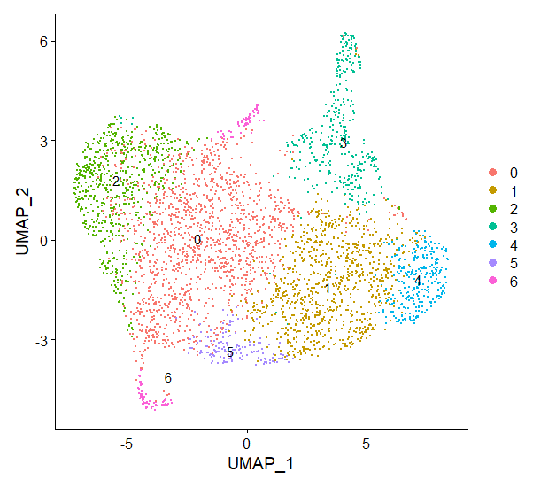

Carlos_UMAP

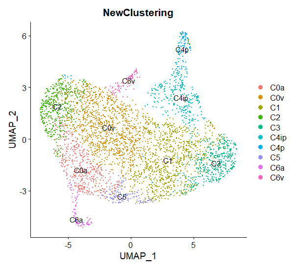

Carlos_UMAP_New_Clustering

## 1.2 Liver Integration 2 weeks. 7 dimensions

Lets quickly remind how it looked with 7 dims

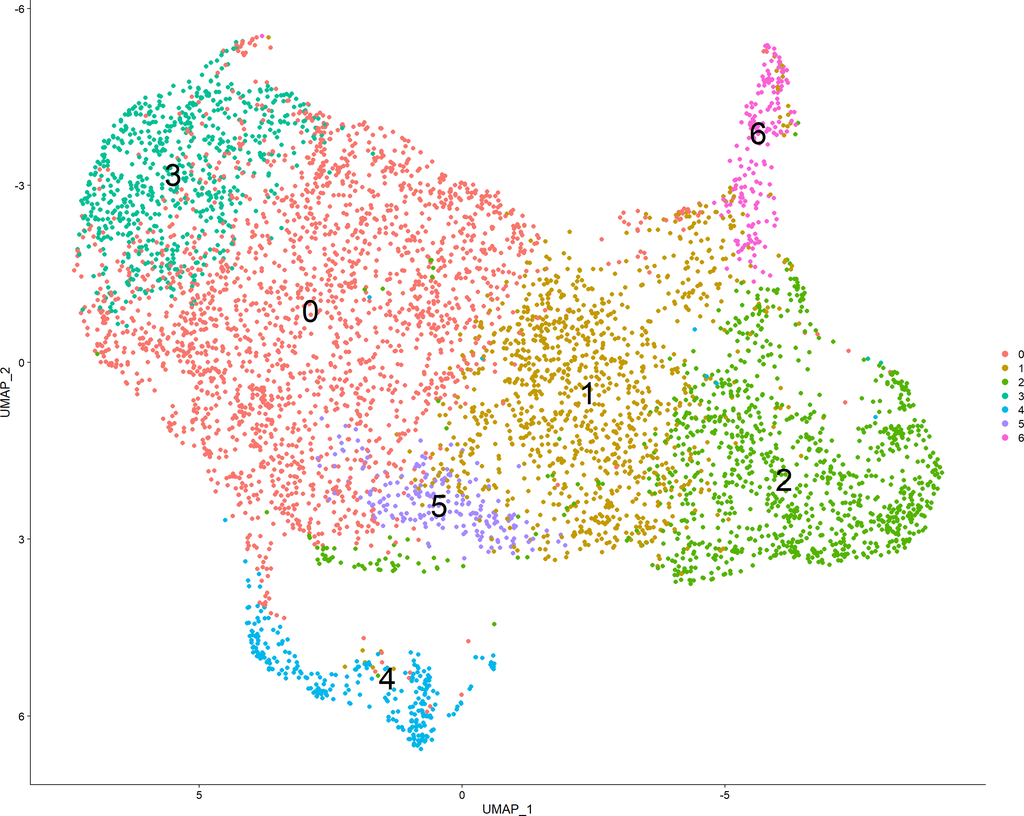

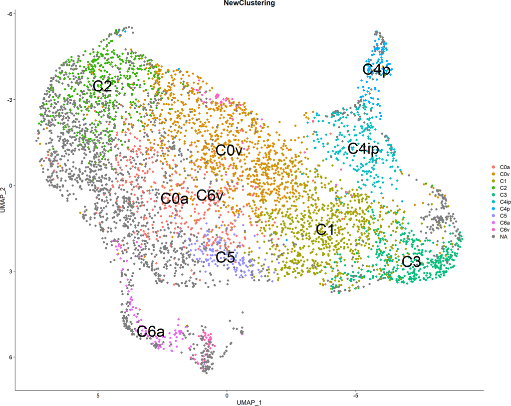

## 1.3 Liver Integration 2 weeks. 6 dimensions. Reestructuring with min distance and n neighbors

I saw that with 6 dimensions I was able to keep the AV zonation, however the plot looked a bit messier

SO let’s quickly look at it.

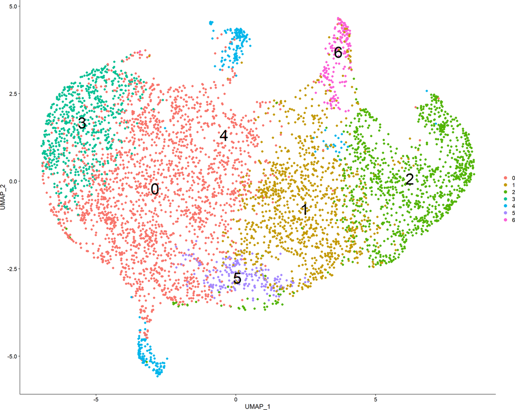

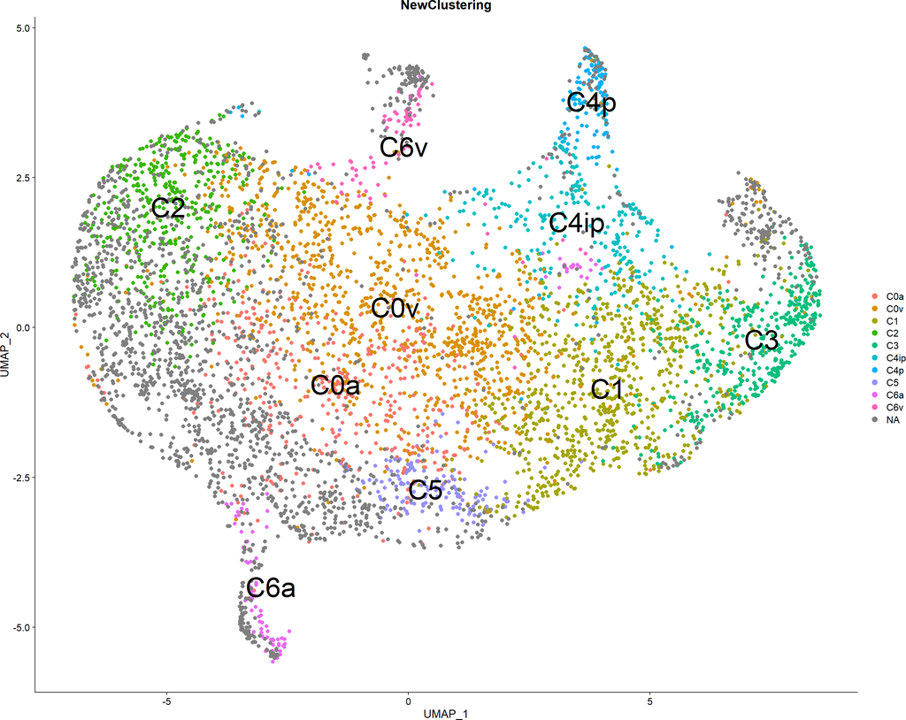

So with 6 dimensions the AZ zonation is kept but cluster 4 looks a bit weird (ArterioVenous) and the cells look a bit over the place.

UMAPs have two key parameters, minimal distance and number of neighbors. Since we want to boost the global structure over the local y will do a run of different settings of these two parameters under 6 dimensions so I can get a more compacted, globally clear UMAP.

I will start with distances. I will go from 0-0.8, making a 0.1 increment for each iteration

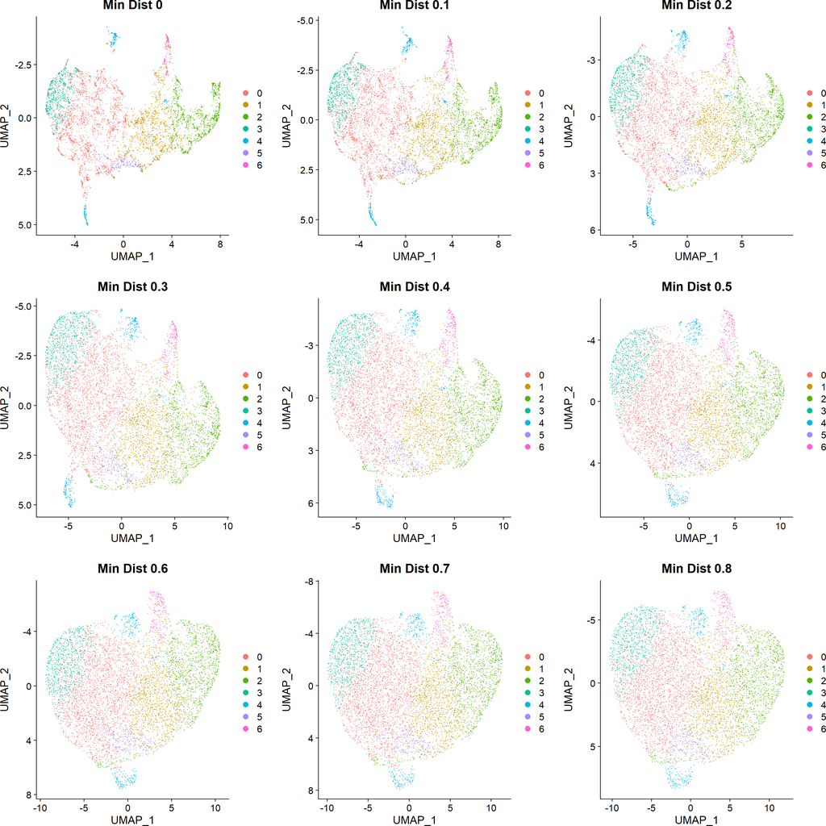

It seems like 0.2 is the best distance. I will go onto calculating the best neighbor number.

I will go from 30 to 110 neighbors, increasing 10 by 10 in each iteration.

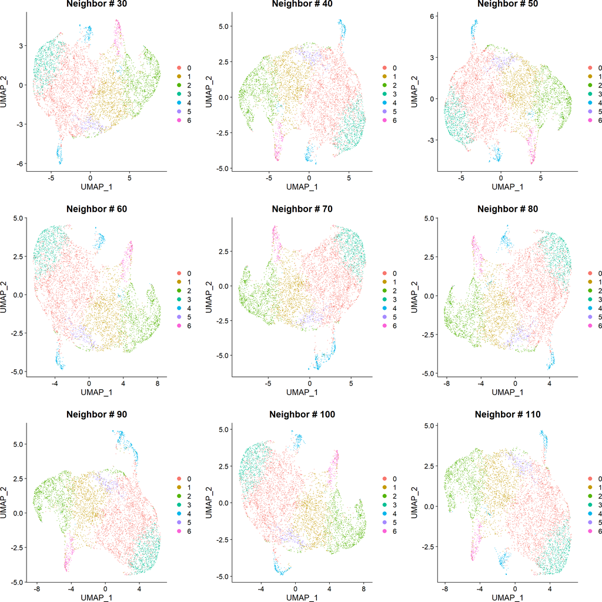

I conclude that the best settings to preserve the global structure Rui wants is setting up for a min.dist of 0.2 and n.neighbor of 100.

I will save this umap with the name: “umap_6d_0.2dist_100n”

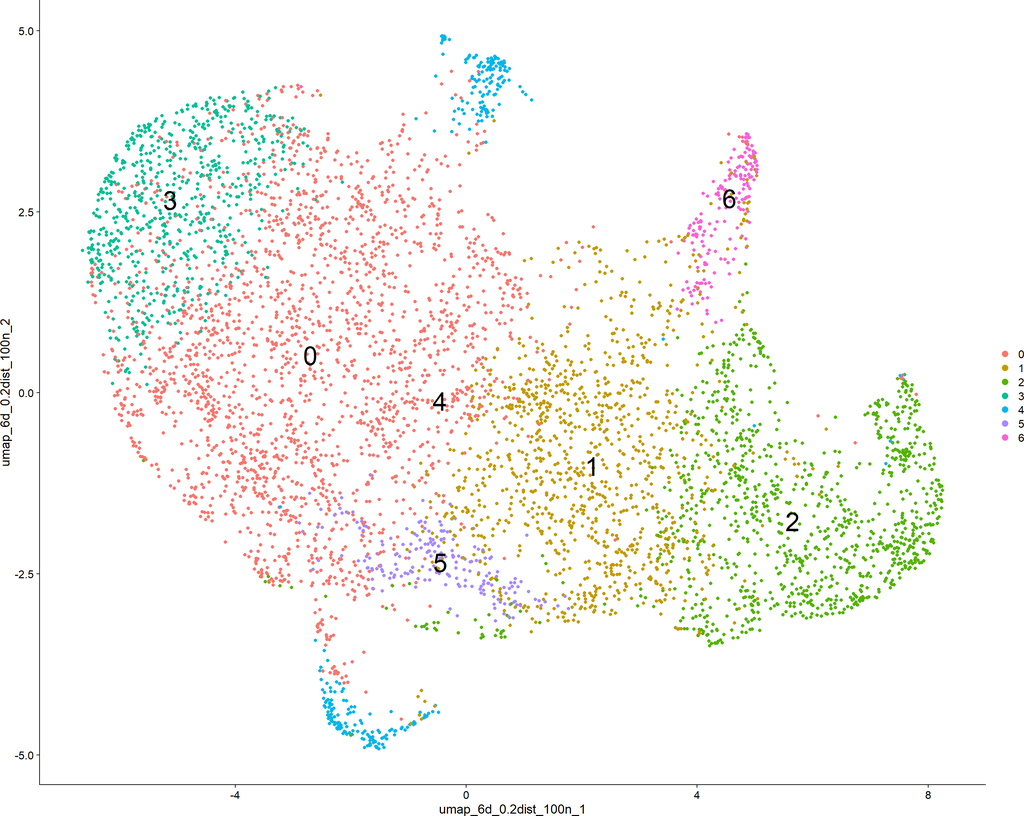

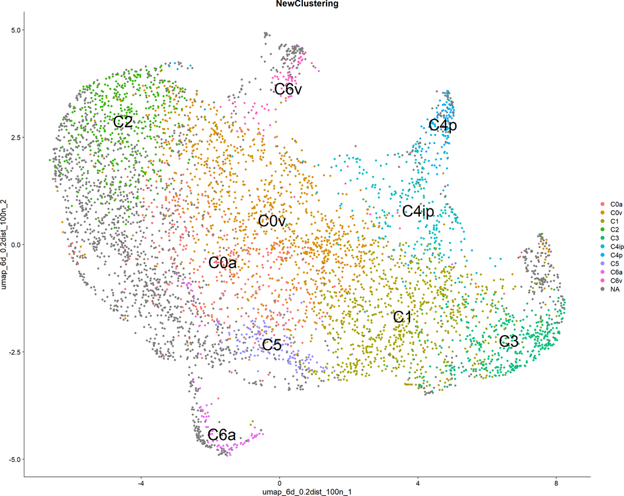

## 1.4 Clustering like Carlos

After many different settings I have come up with this configuration for the final Clustering

```
## Modularity Optimizer version 1.3.0 by Ludo Waltman and Nees Jan van Eck
##
## Number of nodes: 5707
## Number of edges: 215373
##
## Running Louvain algorithm...
## Maximum modularity in 10 random starts: 0.8886
## Number of communities: 7
## Elapsed time: 0 seconds
```

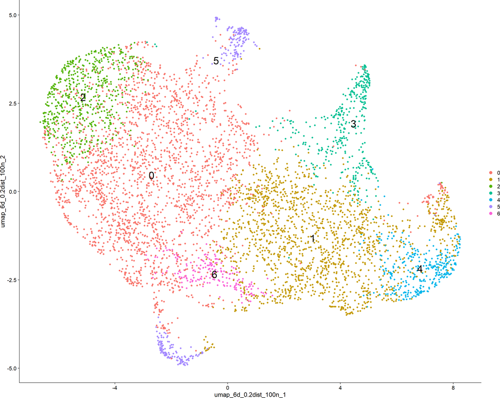

# 2 Conclusion

By tweaking the min distance values and n neighbors I have produced a plot that better preserves the global structure of the Liver 2 weeks scRNASeq sample. Next I will plot the general markers onto this final UMAP